# BIOL3100 Final Project

Jessica Richards

2024-11-30

# Tree Seedling Survival Responses Data

### Source

Original Dataset

Link to original authors: https://doi.org/10.5061/dryad.xd2547dpw

Citation: Wood, K., Kobe, R., Ibáñez, I., *et al.* (2023). Tree seedling functional traits mediate plant-soil feedback survival responses across a gradient of light availability. Dryad. https://doi.org/10.5061/dryad.xd2547dpw

Study Funded by: National Science Foundation: NSF DEB 145732, Michigan State University, and Alma College

### About the data

Introduction to Data:

The purpose of the study was to see how functional traits mediate plant-soil feedbacks (PSFs) via seedling survival.

Methods:

This study was a factorial blocked design field experiment. 4 tree species (*Acer saccharum, Prunus serotina, Quercus alba,* and *Quercus rubra*), 7 soil sources (*Acer saccharum, Prunus serotina, Quercus alba, Quercus rubra, Acer rebrum, Populus grandidentata*, and Sterilized) and a variety of forest understory light levels were used. There were a total of 3,024 seedlings in this experiment. Survival was measured twice a week and at 3 weeks, some seedlings were randomly selected to measure mycorrhizal colonization, phenolics, lignin, and NSC.

Column information:

- No: Seedling ID number
- Plot: Plot the seedling was planted in (1-18)
- Subplot: Subplot seedling was planted in (A-E, one per corner and one in the middle)
- Species: Species of seedling (*Acer saccharum, Prunus serotina, Quercus alba*, and *Quercus rubra*)
- Light_ISF: Light level based on HemiView software.
- Light_Cat: Light levels were categorized into ‘Low’ ‘Med’ or ‘High’
- Core: Year the soil core was taken, either 2016 or 2017
- Soil: Which species the soil core was taken from. Includes all 4 species as well as *Acer rubrum, Populus grandidentata* and a sterilized conspecific of each species
- Adult: Indicates which adult tree the soil core came from, up to 6 adults per species.
- Sterile: Indicates whether the soil was steralized or not
- Conspecific: Indicates if the soil core used was from it’s own species (conspecific), a different species (heterospecific) or steralized (sterile)
- Myco: Mycorrhizal type of the seedling (AMF or EMF)
- SoilMyco: Mycorrhizal type of the soil (AMF, EMF or Sterile)
- PlantDate: Date each tree was planted
- AMF: Measures the percent arbuscular mycorrhizal fungi colonization on fine roots of harvested seedlings
- EMF: Measures the percent ectomycorrhizal fungi colonization on the root tips of harvested seedlings
- Phenolics: Calculated as nmol Gallic acid equivalents per mg dry extract
- NSC: Calculated as the percent dry mass non-structural carbohydrates
- Lignin: Measured as percent dry mass lignin
- Census: The census number when each seedling died or was harvested
- Time: The number of days before the seedling died or was harvested
- Event: Indicates whether the seedling died during the study (1 = dead, 0 = harvested or alive at end of study)
- Harvest: Indicates whether the seedling was harvested during the study
- Alive: Indicates whether the seedling was alive at the end of the study

### Focus for Data Analysis

The focus for this data analysis will be on how different environmental factors affect the amount of phenolics, lignin, and NSC (non-structural carbohydrates) in seedlings of different tree species. The main factors that will be analyzed are Light_Cat, Conspecific, SoilMyco, AMF and EMF.

## Original Data

### Output

Preview of Original Data

```
## Rows: 2,783
## Columns: 24
## $ No          <int> 126, 11, 12, 2823, 5679, 18, 25, 40, 26, 41, 30, 33, 34, 3…
## $ Plot        <int> 1, 1, 1, 7, 14, 1, 1, 1, 1, 1, 1, 1, 1, 1, 1, 1, 1, 1, 1, …
## $ Subplot     <chr> "C", "C", "C", "D", "A", "C", "A", "A", "A", "A", "C", "C"…
## $ Species     <chr> "Acer saccharum", "Quercus alba", "Quercus rubra", "Acer s…
## $ Light_ISF   <dbl> 0.106, 0.106, 0.106, 0.080, 0.060, 0.106, 0.108, 0.108, 0.…
## $ Light_Cat   <chr> "Med", "Med", "Med", "Med", "Low", "Med", "Med", "Med", "M…
## $ Core        <int> 2017, 2017, 2017, 2016, 2017, 2016, 2016, 2017, 2016, 2016…
## $ Soil        <chr> "Prunus serotina", "Quercus rubra", "Prunus serotina", "Pr…
## $ Adult       <chr> "I", "970", "J", "J", "689", "1332", "891", "1595", "1323"…
## $ Sterile     <chr> "Non-Sterile", "Non-Sterile", "Non-Sterile", "Non-Sterile"…
## $ Conspecific <chr> "Heterospecific", "Heterospecific", "Heterospecific", "Het…
## $ Myco        <chr> "AMF", "EMF", "EMF", "AMF", "AMF", "AMF", "EMF", "EMF", "E…
## $ SoilMyco    <chr> "AMF", "EMF", "AMF", "AMF", "AMF", "AMF", "EMF", "Sterile"…
## $ PlantDate   <chr> "6/11/18", "5/25/18", "5/31/18", "6/11/18", "6/11/18", "6/…
## $ AMF         <dbl> 22.00, 15.82, 24.45, 22.23, 21.15, 35.29, 24.00, 4.00, 28.…
## $ EMF         <dbl> NA, 31.07, 28.19, NA, NA, NA, 20.00, 0.00, 36.18, NA, 28.1…
## $ Phenolics   <dbl> -0.56, 5.19, 3.36, -0.71, -0.58, 0.30, 5.11, 3.43, 3.83, -…
## $ Lignin      <dbl> 13.86, 20.52, 24.74, 14.29, 10.85, 10.80, 18.82, 25.22, 26…
## $ NSC         <dbl> 12.15, 19.29, 15.01, 12.36, 11.20, 13.79, 22.51, 14.81, 14…
## $ Census      <int> 4, 33, 18, 4, 4, 7, 7, 7, 33, 7, 33, 21, 21, 17, 7, 33, 7,…
## $ Time        <dbl> 14.0, 115.5, 63.0, 14.0, 14.0, 24.5, 24.5, 24.5, 115.5, 24…
## $ Event       <int> 1, 0, 1, 1, 1, 1, 0, 0, 0, 1, 0, 1, 1, 1, 0, 0, 0, 0, 0, 1…
## $ Harvest     <chr> NA, NA, NA, NA, NA, NA, "X", "X", NA, NA, NA, NA, NA, NA, …
## $ Alive       <chr> NA, "X", NA, NA, NA, NA, NA, NA, "X", NA, "X", NA, NA, NA,…
```

### R code

Preview of Original Data

```r
tree_dat <- read.csv('Tree_Data.csv')
glimpse(tree_dat)
```

```
## Rows: 2,783
## Columns: 24
## $ No          <int> 126, 11, 12, 2823, 5679, 18, 25, 40, 26, 41, 30, 33, 34, 3…
## $ Plot        <int> 1, 1, 1, 7, 14, 1, 1, 1, 1, 1, 1, 1, 1, 1, 1, 1, 1, 1, 1, …
## $ Subplot     <chr> "C", "C", "C", "D", "A", "C", "A", "A", "A", "A", "C", "C"…
## $ Species     <chr> "Acer saccharum", "Quercus alba", "Quercus rubra", "Acer s…
## $ Light_ISF   <dbl> 0.106, 0.106, 0.106, 0.080, 0.060, 0.106, 0.108, 0.108, 0.…
## $ Light_Cat   <chr> "Med", "Med", "Med", "Med", "Low", "Med", "Med", "Med", "M…
## $ Core        <int> 2017, 2017, 2017, 2016, 2017, 2016, 2016, 2017, 2016, 2016…
## $ Soil        <chr> "Prunus serotina", "Quercus rubra", "Prunus serotina", "Pr…
## $ Adult       <chr> "I", "970", "J", "J", "689", "1332", "891", "1595", "1323"…
## $ Sterile     <chr> "Non-Sterile", "Non-Sterile", "Non-Sterile", "Non-Sterile"…
## $ Conspecific <chr> "Heterospecific", "Heterospecific", "Heterospecific", "Het…
## $ Myco        <chr> "AMF", "EMF", "EMF", "AMF", "AMF", "AMF", "EMF", "EMF", "E…
## $ SoilMyco    <chr> "AMF", "EMF", "AMF", "AMF", "AMF", "AMF", "EMF", "Sterile"…
## $ PlantDate   <chr> "6/11/18", "5/25/18", "5/31/18", "6/11/18", "6/11/18", "6/…
## $ AMF         <dbl> 22.00, 15.82, 24.45, 22.23, 21.15, 35.29, 24.00, 4.00, 28.…
## $ EMF         <dbl> NA, 31.07, 28.19, NA, NA, NA, 20.00, 0.00, 36.18, NA, 28.1…
## $ Phenolics   <dbl> -0.56, 5.19, 3.36, -0.71, -0.58, 0.30, 5.11, 3.43, 3.83, -…
## $ Lignin      <dbl> 13.86, 20.52, 24.74, 14.29, 10.85, 10.80, 18.82, 25.22, 26…
## $ NSC         <dbl> 12.15, 19.29, 15.01, 12.36, 11.20, 13.79, 22.51, 14.81, 14…
## $ Census      <int> 4, 33, 18, 4, 4, 7, 7, 7, 33, 7, 33, 21, 21, 17, 7, 33, 7,…
## $ Time        <dbl> 14.0, 115.5, 63.0, 14.0, 14.0, 24.5, 24.5, 24.5, 115.5, 24…
## $ Event       <int> 1, 0, 1, 1, 1, 1, 0, 0, 0, 1, 0, 1, 1, 1, 0, 0, 0, 0, 0, 1…
## $ Harvest     <chr> NA, NA, NA, NA, NA, NA, "X", "X", NA, NA, NA, NA, NA, NA, …
## $ Alive       <chr> NA, "X", NA, NA, NA, NA, NA, NA, "X", NA, "X", NA, NA, NA,…
```

# Cleaned Data

## Cleaned Data

### Output

The cleaned data has less columns and is better for plotting/modeling.

- Columns removed: Light_ISF, Core, Sterile, Adult, PlantDate, Census
- Columns ‘Event’, ‘Harvest’, and ‘Alive’ merged into one column called ‘Event’ that indicates whether a tree died, was harvested, or was alive at the end of the study.

```
## Rows: 2,782
## Columns: 16
## $ No          <int> 126, 11, 12, 2823, 5679, 18, 25, 40, 26, 41, 30, 33, 34, 3…
## $ Plot        <int> 1, 1, 1, 7, 14, 1, 1, 1, 1, 1, 1, 1, 1, 1, 1, 1, 1, 1, 1, …
## $ Subplot     <chr> "C", "C", "C", "D", "A", "C", "A", "A", "A", "A", "C", "C"…
## $ Species     <chr> "Acer saccharum", "Quercus alba", "Quercus rubra", "Acer s…
## $ Light_Cat   <chr> "Med", "Med", "Med", "Med", "Low", "Med", "Med", "Med", "M…
## $ Soil        <chr> "Prunus serotina", "Quercus rubra", "Prunus serotina", "Pr…
## $ Conspecific <chr> "Heterospecific", "Heterospecific", "Heterospecific", "Het…
## $ Myco        <chr> "AMF", "EMF", "EMF", "AMF", "AMF", "AMF", "EMF", "EMF", "E…
## $ SoilMyco    <chr> "AMF", "EMF", "AMF", "AMF", "AMF", "AMF", "EMF", "Sterile"…
## $ AMF         <dbl> 22.00, 15.82, 24.45, 22.23, 21.15, 35.29, 24.00, 4.00, 28.…
## $ EMF         <dbl> NA, 31.07, 28.19, NA, NA, NA, 20.00, 0.00, 36.18, NA, 28.1…
## $ Phenolics   <dbl> -0.56, 5.19, 3.36, -0.71, -0.58, 0.30, 5.11, 3.43, 3.83, -…
## $ Lignin      <dbl> 13.86, 20.52, 24.74, 14.29, 10.85, 10.80, 18.82, 25.22, 26…
## $ NSC         <dbl> 12.15, 19.29, 15.01, 12.36, 11.20, 13.79, 22.51, 14.81, 14…
## $ Time        <dbl> 14.0, 115.5, 63.0, 14.0, 14.0, 24.5, 24.5, 24.5, 115.5, 24…
## $ Event       <chr> "Dead", "Alive", "Dead", "Dead", "Dead", "Dead", "Harvest"…
```

### R code

The cleaned data has less columns and is better for plotting/modeling.

- Columns removed: Light_ISF, Core, Sterile, Adult, PlantDate, Census
- Columns ‘Event’, ‘Harvest’, and ‘Alive’ merged into one column called ‘Event’ that indicates whether a tree died, was harvested, or was alive at the end of the study

```r
tree_dat_clean <- tree_dat %>%
  select(-c(Light_ISF, Core, Sterile, Adult, PlantDate, Census)) %>%
  mutate(Event = case_when(
    Event == '1' ~ 'X',
    Event == '0' ~ NA_character_)) %>%
  pivot_longer(cols = c(Event, Harvest, Alive),
               names_to = 'Event',
               values_to = 'Status') %>%
  mutate(Event = case_when(
    Event == 'Event' ~ 'Dead',
    TRUE ~ Event  )) %>%
  drop_na(Status) %>%
  select(-Status)

glimpse(tree_dat_clean)
```

```
## Rows: 2,782
## Columns: 16
## $ No          <int> 126, 11, 12, 2823, 5679, 18, 25, 40, 26, 41, 30, 33, 34, 3…
## $ Plot        <int> 1, 1, 1, 7, 14, 1, 1, 1, 1, 1, 1, 1, 1, 1, 1, 1, 1, 1, 1, …
## $ Subplot     <chr> "C", "C", "C", "D", "A", "C", "A", "A", "A", "A", "C", "C"…
## $ Species     <chr> "Acer saccharum", "Quercus alba", "Quercus rubra", "Acer s…
## $ Light_Cat   <chr> "Med", "Med", "Med", "Med", "Low", "Med", "Med", "Med", "M…
## $ Soil        <chr> "Prunus serotina", "Quercus rubra", "Prunus serotina", "Pr…
## $ Conspecific <chr> "Heterospecific", "Heterospecific", "Heterospecific", "Het…
## $ Myco        <chr> "AMF", "EMF", "EMF", "AMF", "AMF", "AMF", "EMF", "EMF", "E…
## $ SoilMyco    <chr> "AMF", "EMF", "AMF", "AMF", "AMF", "AMF", "EMF", "Sterile"…
## $ AMF         <dbl> 22.00, 15.82, 24.45, 22.23, 21.15, 35.29, 24.00, 4.00, 28.…
## $ EMF         <dbl> NA, 31.07, 28.19, NA, NA, NA, 20.00, 0.00, 36.18, NA, 28.1…
## $ Phenolics   <dbl> -0.56, 5.19, 3.36, -0.71, -0.58, 0.30, 5.11, 3.43, 3.83, -…
## $ Lignin      <dbl> 13.86, 20.52, 24.74, 14.29, 10.85, 10.80, 18.82, 25.22, 26…
## $ NSC         <dbl> 12.15, 19.29, 15.01, 12.36, 11.20, 13.79, 22.51, 14.81, 14…
## $ Time        <dbl> 14.0, 115.5, 63.0, 14.0, 14.0, 24.5, 24.5, 24.5, 115.5, 24…
## $ Event       <chr> "Dead", "Alive", "Dead", "Dead", "Dead", "Dead", "Harvest"…
```

# Plotting Data

## NSC against Lignin with Light_Cat as color

### Output

In *Acer saccharum* and *Prunus serotina*, NSC and Lignin have a positive relationship. High and Med light levels seem to result in higher levels of both NSC and Lignin compared to Low light levels.

In *Quercus alba* and *Quercus rubra*, NSC and Lignin have a negative relationship. While NSC and Lignin levels are comparable across light levels in *Q. alba*, it seems that low light levels in *Q. rubra* may be associated with lower levels of NSC.

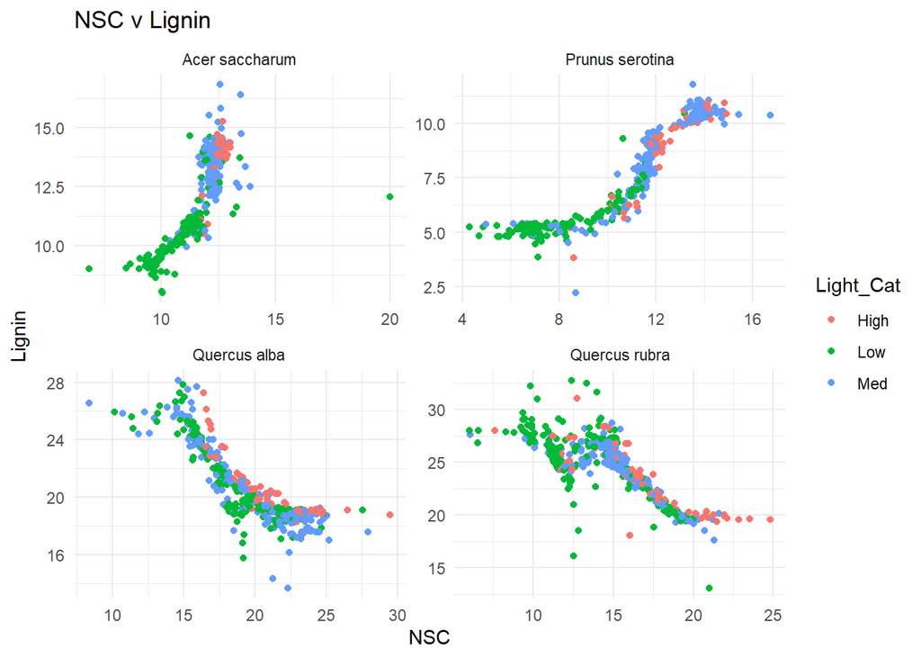

### R code

In *Acer saccharum* and *Prunus serotina*, NSC and Lignin have a positive relationship. High and Med light levels seem to result in higher levels of both NSC and Lignin compared to Low light levels.

In *Quercus alba* and *Quercus rubra*, NSC and Lignin have a negative relationship. While NSC and Lignin levels are comparable across light levels in *Q. alba*, it seems that low light levels in *Q. rubra* may be associated with lower levels of NSC.

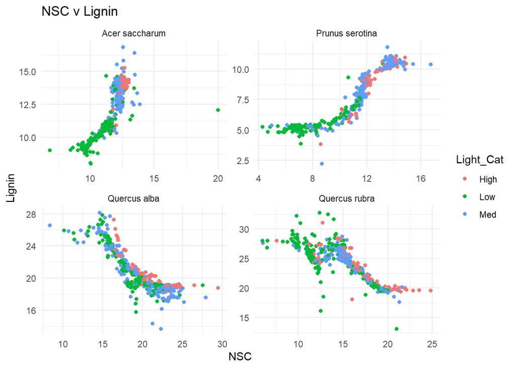

```r
tree_dat_clean %>%
  ggplot(aes(x = NSC,
             y = Lignin,
             color = Light_Cat)) +
  geom_point() +
  facet_wrap(~Species, scales = 'free') +
  theme_minimal() +
  ggtitle('NSC v Lignin')
```

## Phenolics against AMF with Light_Cat as color

### Output

Percent dry mass Phenolics and percent AMF have a positive relationship in *Prunus serotina*.

There also seems to be a trend of higher light categories having a higher percentage of Phenolics.

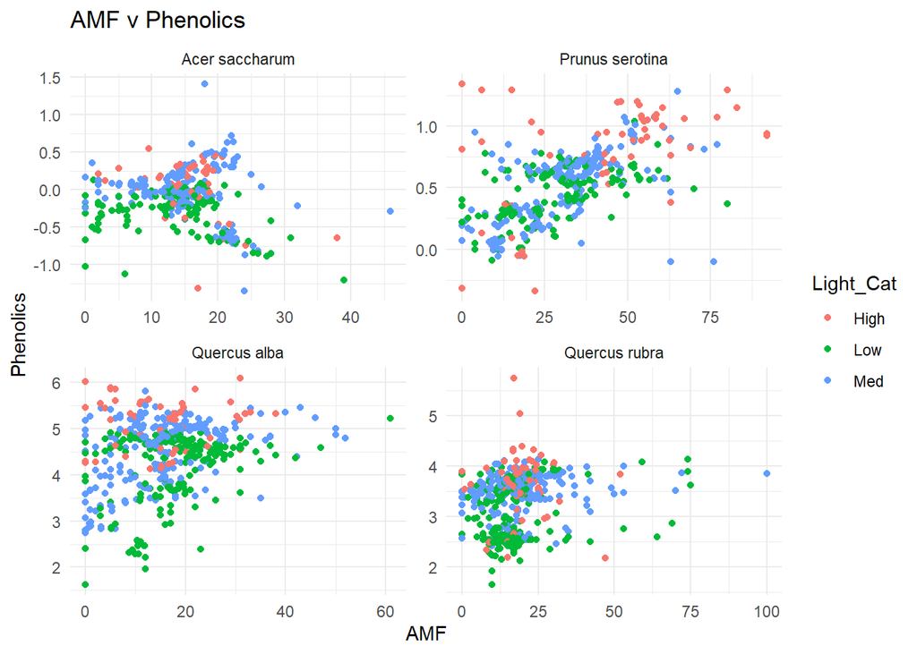

### R code

Percent dry mass Phenolics and percent AMF have a positive relationship in *Prunus serotina*.

There also seems to be a trend of higher light categories having a higher percentage of Phenolics.

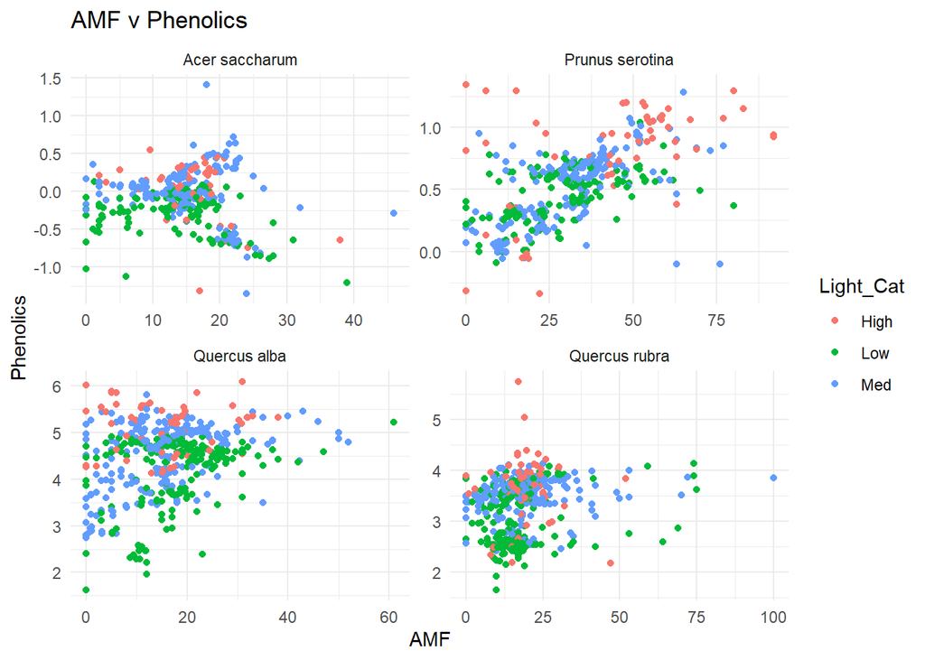

```r
tree_dat_clean %>%
  ggplot(aes(x = AMF,
             y = Phenolics,
             color = Light_Cat)) +
  geom_point() +
  facet_wrap(~Species, scales = 'free') +
  theme_minimal() +
  ggtitle('AMF v Phenolics')
```

## Phenolics against SoilMyco

### Output

*Q. alba* seems to have lower Phenolic levels when in sterilized soil compared to soils with AMF or EMF. *P. serotina* also seems to have lower levels of Phenolics in sterilized soils.

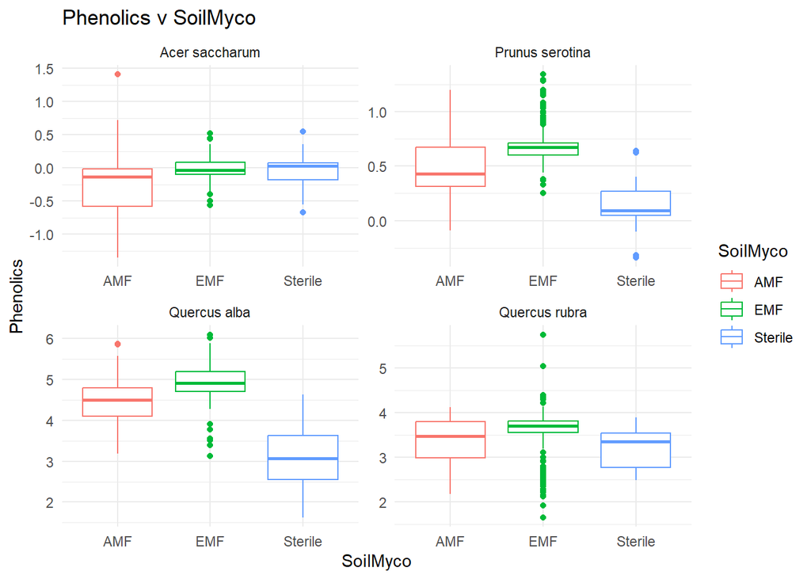

### R code

*Q. alba* seems to have lower Phenolic levels when in sterilized soil compared to soils with AMF or EMF. *P. serotina* also seems to have lower levels of Phenolics in sterilized soils.

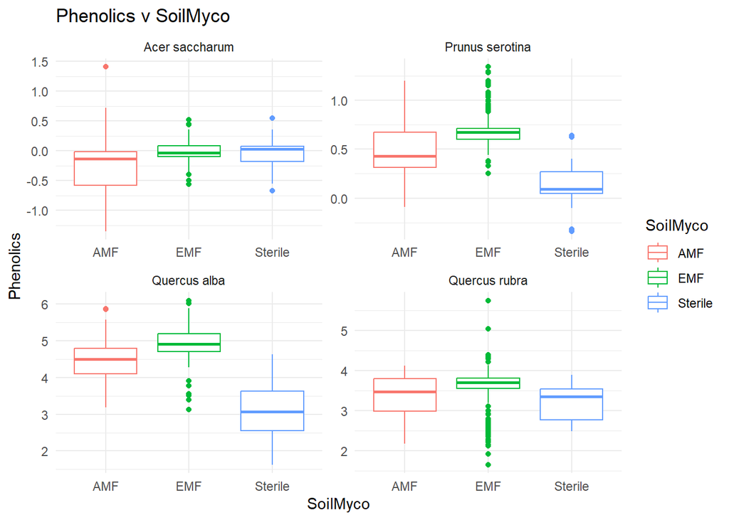

```r
tree_dat_clean %>%
  ggplot(aes(x = SoilMyco,
             y = Phenolics,
             color = SoilMyco)) +
  geom_boxplot() +
  facet_wrap(~Species, scales = 'free') +
  theme_minimal() +
  ggtitle('Phenolics v SoilMyco')
```

## Light_Cat against Phenolics, Lignin, and NSC

### Output

*A. saccharum, P. serotina* and *Q. alba* seem to have higher levels of Phenolics with more higher light. Q. rubra only seems to have higher Phenolic levels in the High light category and the difference is not as dramatic as it is in the other 3 species.

*P. serotina* seems to have higher levels of both Lignin and NSC when in High and Med light categories. Relationships between Light_Cat and Lignin and Light_Cat and NSC are more difficult to see in the other 3 species.

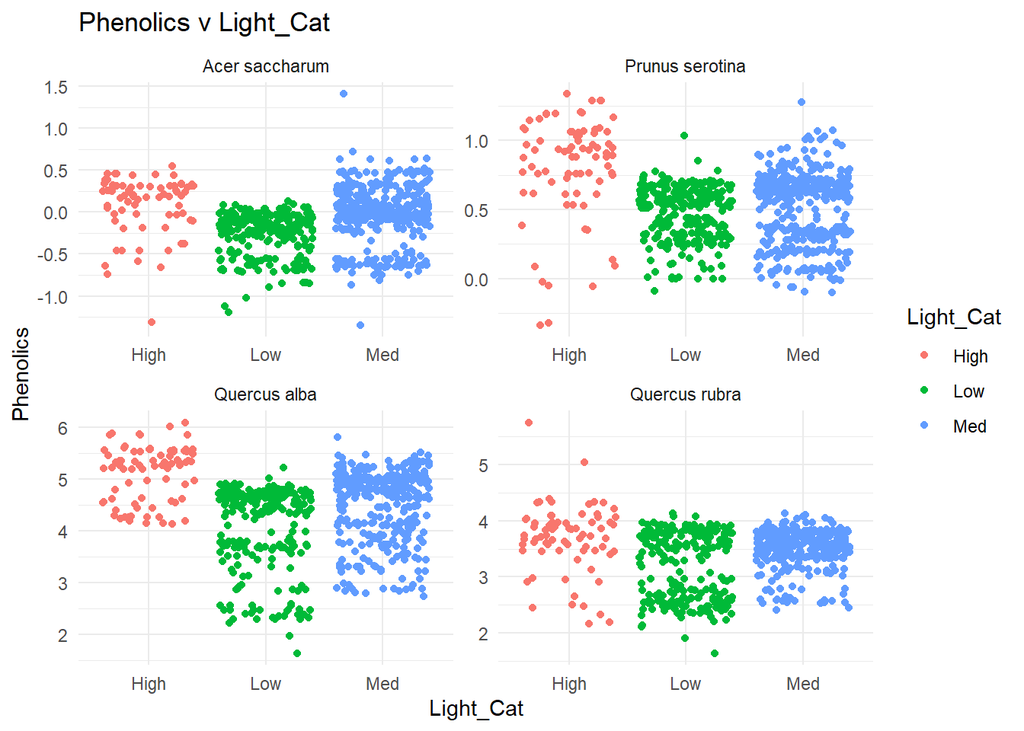

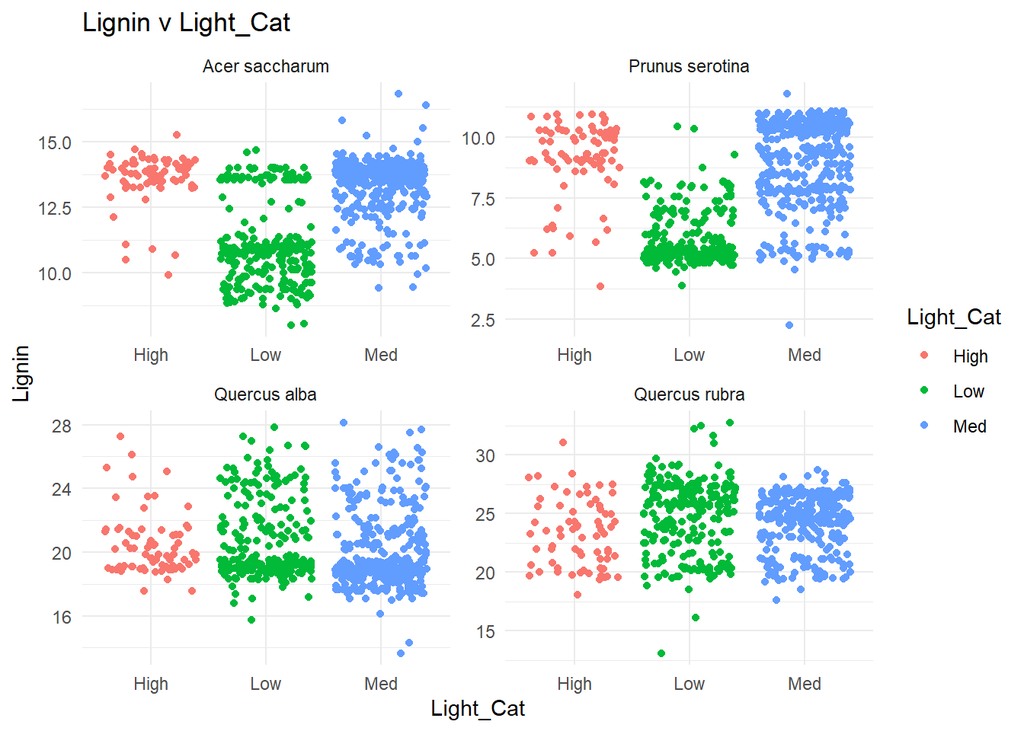

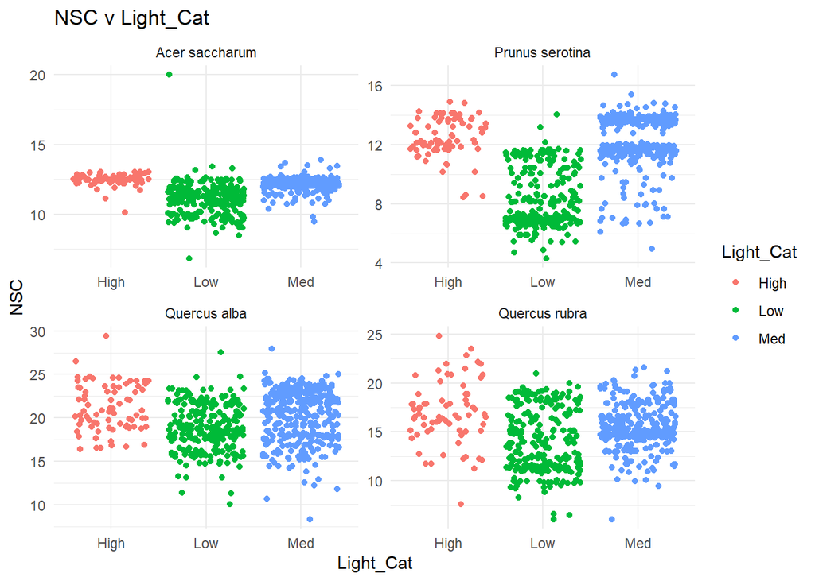

### R code

*A. saccharum, P. serotina* and *Q. alba* seem to have higher levels of Phenolics with more higher light. Q. rubra only seems to have higher Phenolic levels in the High light category and the difference is not as dramatic as it is in the other 3 species.

*P. serotina* seems to have higher levels of both Lignin and NSC when in High and Med light categories. Relationships between Light_Cat and Lignin and Light_Cat and NSC are more difficult to see in the other 3 species.

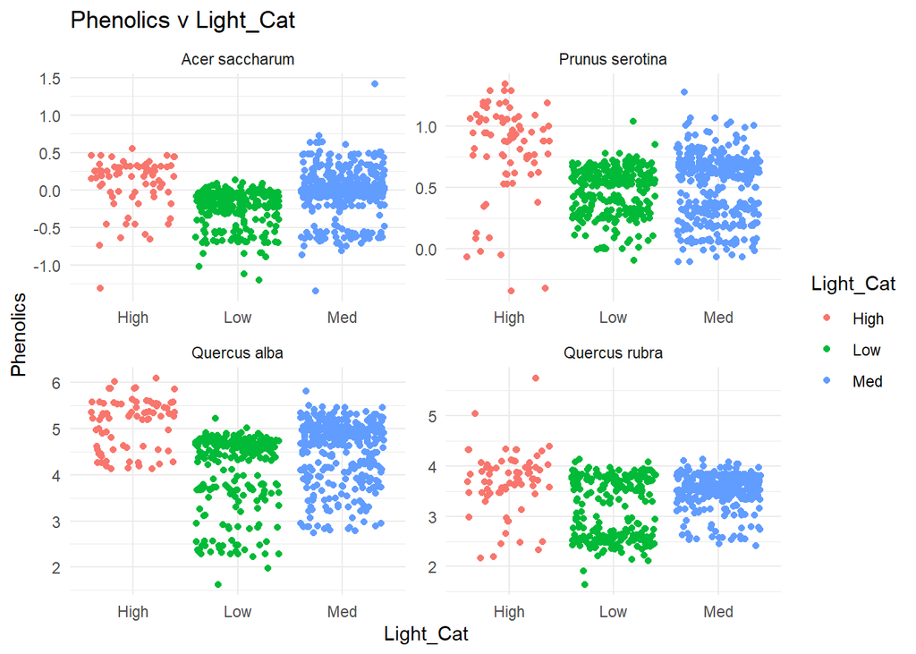

```r
tree_dat_clean %>%
  ggplot(aes(x = Light_Cat,
             y = Phenolics,
             color = Light_Cat)) +
  geom_jitter() +
  facet_wrap(~Species, scales = 'free') +
  theme_minimal() +
    ggtitle('Phenolics v Light_Cat')
```

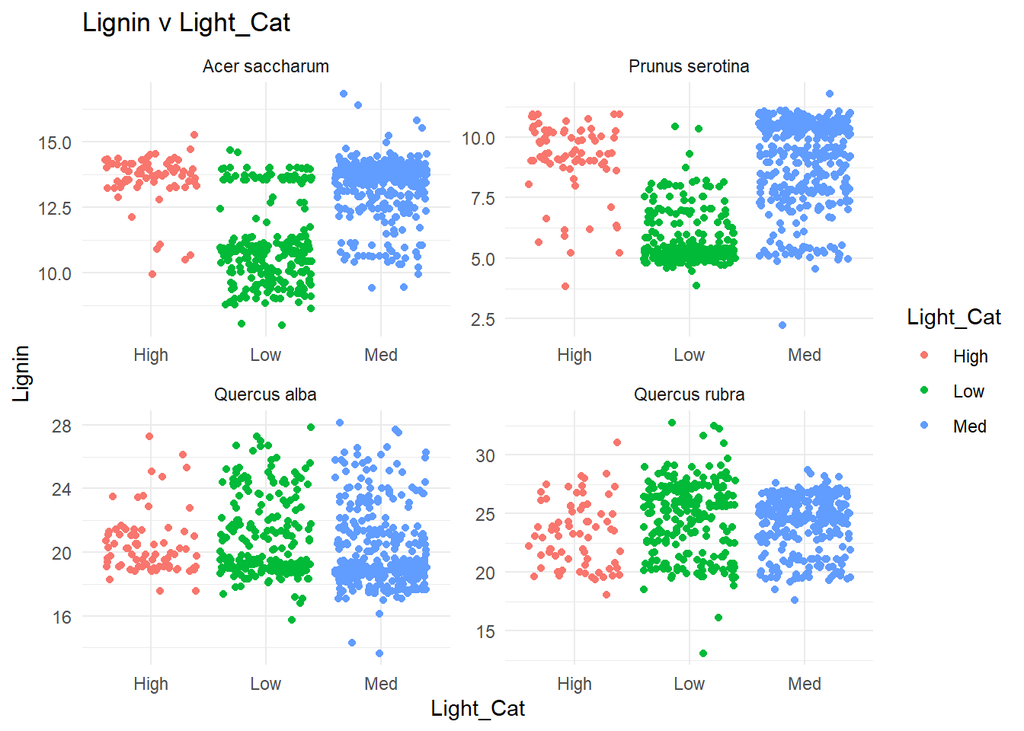

```r
tree_dat_clean %>%
  ggplot(aes(x = Light_Cat,
             y = Lignin,
             color = Light_Cat)) +
  geom_jitter() +
  facet_wrap(~Species, scales = 'free') +
    theme_minimal() +
    ggtitle('Lignin v Light_Cat')
```

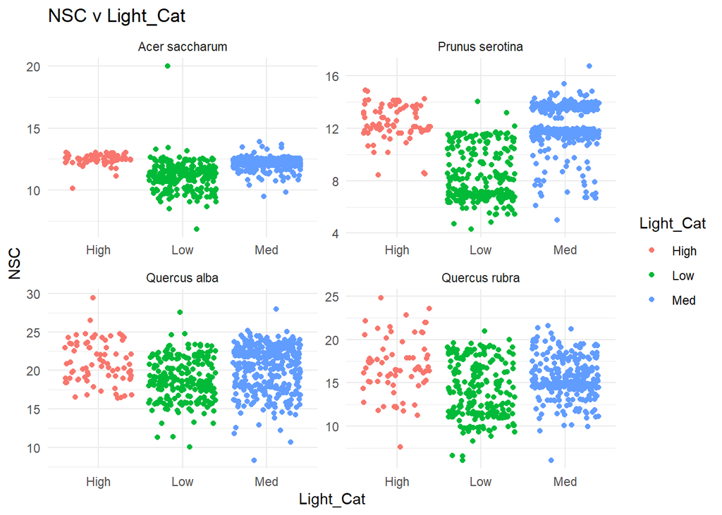

```r
tree_dat_clean %>%
  ggplot(aes(x = Light_Cat,
             y = NSC,
             color = Light_Cat)) +
  geom_jitter() +
  facet_wrap(~Species, scales = 'free') +
    theme_minimal() +
    ggtitle('NSC v Light_Cat')
```

# Modeling Data

## Choosing a Model

### Output

I created 3 models, one to predict Phenolics, one to predict Lignin, and one to predict NSC. Through testing various models, I came to the conclusion that the best formula predicted the dependent variable (Phenolics, Lignin, or NSC) based on the interaction of Conspecific, Species, SoilMyco, and Light_Cat. (check r code for more info on models)

These are represented as mod1 for Phenolics, mod4 for Lignin, and mod7 for NSC.

The model for Phenolics was the most accurate out of the three as it had the highest r-squared and a relatively low AIC. The models for Lignin and NSC had pretty good r-squared values but also had very high AIC values, meaning they likely won’t be as good at predicting values.

```
## [1] "Model for Phenolics"
```

```
## # Comparison of Model Performance Indices
##
## Name | Model |  AIC (weights) | AICc (weights) |  BIC (weights) |    R2 |  RMSE | Sigma
## ---------------------------------------------------------------------------------------
## mod1 |   glm | 1258.7 (>.999) | 1260.5 (>.999) | 1549.3 (>.999) | 0.977 | 0.298 | 0.301
## mod2 |   glm | 1636.1 (<.001) | 1640.1 (<.001) | 2069.1 (<.001) | 0.974 | 0.316 | 0.320
## mod3 |   glm | 1842.7 (<.001) | 1843.7 (<.001) | 2062.1 (<.001) | 0.971 | 0.333 | 0.335
```

```
## [1] "Model for Lignin"
```

```
## # Comparison of Model Performance Indices
##
## Name | Model |   AIC (weights) |  AICc (weights) |   BIC (weights) |    R2 |  RMSE | Sigma
## ------------------------------------------------------------------------------------------
## mod4 |   glm | 11205.2 (>.999) | 11207.0 (>.999) | 11495.8 (>.999) | 0.931 | 1.781 | 1.797
## mod5 |   glm | 11448.6 (<.001) | 11449.6 (<.001) | 11668.0 (<.001) | 0.924 | 1.869 | 1.881
## mod6 |   glm | 11536.9 (<.001) | 11537.9 (<.001) | 11756.3 (<.001) | 0.922 | 1.899 | 1.911
```

```
## [1] "Model for NSC"
```

```
## # Comparison of Model Performance Indices
##
## Name  | Model |   AIC (weights) |  AICc (weights) |   BIC (weights) |    R2 |  RMSE | Sigma
## -------------------------------------------------------------------------------------------
## mod7  |   glm | 11555.8 (>.999) | 11557.6 (>.999) | 11846.5 (>.999) | 0.805 | 1.897 | 1.914
## mod8  |   glm | 11829.2 (<.001) | 11830.2 (<.001) | 12048.6 (<.001) | 0.783 | 2.001 | 2.014
## mod9  |   glm | 11870.3 (<.001) | 11871.3 (<.001) | 12089.8 (<.001) | 0.780 | 2.016 | 2.029
## mod10 |   glm | 12247.4 (<.001) | 12247.5 (<.001) | 12300.8 (<.001) | 0.743 | 2.179 | 2.182
```

### R code

I created 3 models, one to predict Phenolics, one to predict Lignin, and one to predict NSC. Through testing various models, I came to the conclusion that the best formula predicted the dependent variable (Phenolics, Lignin, or NSC) based on the interaction of Conspecific, Species, SoilMyco, and Light_Cat. (check r code for more info on models)

These are represented as mod1 for Phenolics, mod4 for Lignin, and mod7 for NSC.

The model for Phenolics was the most accurate out of the three as it had the highest r-squared and a relatively low AIC. The models for Lignin and NSC had pretty good r-squared values but also had very high AIC values, meaning they likely won’t be as good at predicting values.

```r
print('Model for Phenolics')
```

```
## [1] "Model for Phenolics"
```

```r
mod1 <- glm(data = tree_dat_clean, Phenolics ~ Conspecific * Species * SoilMyco * Light_Cat)
mod2 <- glm(data = tree_dat_clean, Phenolics ~ Conspecific * Species * AMF * Light_Cat)
mod3 <- glm(data = tree_dat_clean, Phenolics ~ Conspecific * Species * Light_Cat)

compare_performance(mod1, mod2, mod3)
```

```
## # Comparison of Model Performance Indices
##
## Name | Model |  AIC (weights) | AICc (weights) |  BIC (weights) |    R2 |  RMSE | Sigma
## ---------------------------------------------------------------------------------------
## mod1 |   glm | 1258.7 (>.999) | 1260.5 (>.999) | 1549.3 (>.999) | 0.977 | 0.298 | 0.301
## mod2 |   glm | 1636.1 (<.001) | 1640.1 (<.001) | 2069.1 (<.001) | 0.974 | 0.316 | 0.320
## mod3 |   glm | 1842.7 (<.001) | 1843.7 (<.001) | 2062.1 (<.001) | 0.971 | 0.333 | 0.335
```

```r
print('Model for Lignin')
```

```
## [1] "Model for Lignin"
```

```r
mod4 <- glm(data = tree_dat_clean, Lignin ~ Conspecific * Species * SoilMyco * Light_Cat)
mod5 <- glm(data = tree_dat_clean, Lignin ~ Species * SoilMyco * Light_Cat)
mod6 <- glm(data = tree_dat_clean, Lignin ~ Conspecific * Species * Light_Cat)

compare_performance(mod4, mod5, mod6)
```

```
## # Comparison of Model Performance Indices
##
## Name | Model |   AIC (weights) |  AICc (weights) |   BIC (weights) |    R2 |  RMSE | Sigma
## ------------------------------------------------------------------------------------------
## mod4 |   glm | 11205.2 (>.999) | 11207.0 (>.999) | 11495.8 (>.999) | 0.931 | 1.781 | 1.797
## mod5 |   glm | 11448.6 (<.001) | 11449.6 (<.001) | 11668.0 (<.001) | 0.924 | 1.869 | 1.881
## mod6 |   glm | 11536.9 (<.001) | 11537.9 (<.001) | 11756.3 (<.001) | 0.922 | 1.899 | 1.911
```

```r
print('Model for NSC')
```

```
## [1] "Model for NSC"
```

```r
mod7 <- glm(data = tree_dat_clean, NSC ~ Conspecific * Species * SoilMyco * Light_Cat)
mod8 <- glm(data = tree_dat_clean, NSC ~ Species * SoilMyco * Light_Cat)
mod9 <- glm(data = tree_dat_clean, NSC ~ Conspecific * Species * Light_Cat)
mod10 <- glm(data = tree_dat_clean, NSC ~ Conspecific + Species + Light_Cat)

compare_performance(mod7, mod8, mod9, mod10)
```

```
## # Comparison of Model Performance Indices
##
## Name  | Model |   AIC (weights) |  AICc (weights) |   BIC (weights) |    R2 |  RMSE | Sigma
## -------------------------------------------------------------------------------------------
## mod7  |   glm | 11555.8 (>.999) | 11557.6 (>.999) | 11846.5 (>.999) | 0.805 | 1.897 | 1.914
## mod8  |   glm | 11829.2 (<.001) | 11830.2 (<.001) | 12048.6 (<.001) | 0.783 | 2.001 | 2.014
## mod9  |   glm | 11870.3 (<.001) | 11871.3 (<.001) | 12089.8 (<.001) | 0.780 | 2.016 | 2.029
## mod10 |   glm | 12247.4 (<.001) | 12247.5 (<.001) | 12300.8 (<.001) | 0.743 | 2.179 | 2.182
```

## Phenolics Predictive Modeling

### Output

For predictive modeling of Phenolics in tree seedlings, I first created a dataframe from my clean data (tree_dat_clean) that included predictions based on my chosen model (mod1). A preview of these predictions can be seen below. While not perfect, the predictions do match up relatively well.

Through a series of dataframes and predictions, I predicted Phenolic levels for a new dataframe and plotted these predictions against the real data. For more specific information on how I did this, you can look at the r code.

In the first graph, we can see that the predicted values from the new dataframe line up fairly well with the actual data. This is especially clear in *Q. alba* where the predicted values fall pretty close to the center of the different groups. We can also see the relationships between Phenolics, Light_Cat and Conspecific quite well. *P. serotina* and *Q. alba* don’t do as well in sterile soil across all light categories, and *Q. alba* seems to do consistently best in conspecific soils.

In the second graph we see the same relationships between Phenolics and Light_Cat but we also see SoilMyco’s relationship with Phenolics. It looks like *Q. alba* has high Phenolic levels in EMF soils, slightly less in AMF soils and relatively low levels in Sterile soils. Sterile soils don’t seem to affect *Q. rubra’s* Phenolic levels very much unless it’s in a Low light category. *P. serotina* follows a similar trend to *Q. alba*, but this is confusing because *P. serotina* is categorized as an AMF in the Myco column. It would be expected that it would have higher Phenolic levels in AMF soils.

```
## # A tibble: 2,782 × 2
##    Phenolics    pred
##        <dbl>   <dbl>
##  1     -0.56 -0.348
##  2      5.19  5.03
##  3      3.36  3.46
##  4     -0.71 -0.348
##  5     -0.58 -0.481
##  6      0.3   0.563
##  7      5.11  5.03
##  8      3.43  3.39
##  9      3.83  3.46
## 10     -0.05  0.0244
## # ℹ 2,772 more rows
```

[output not shown]

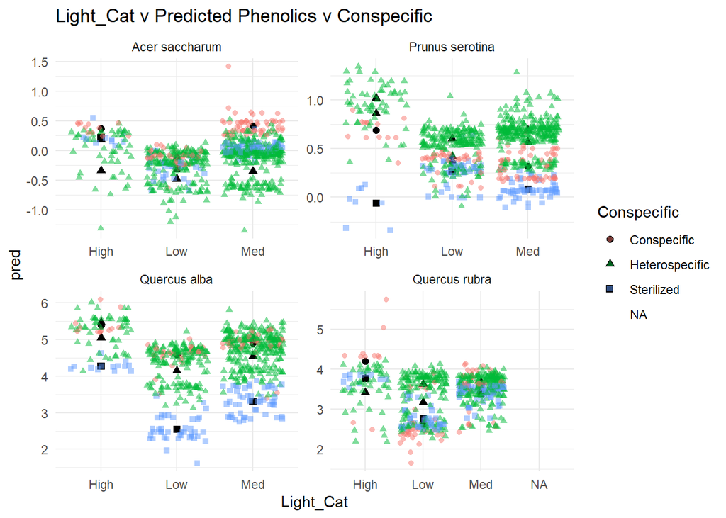

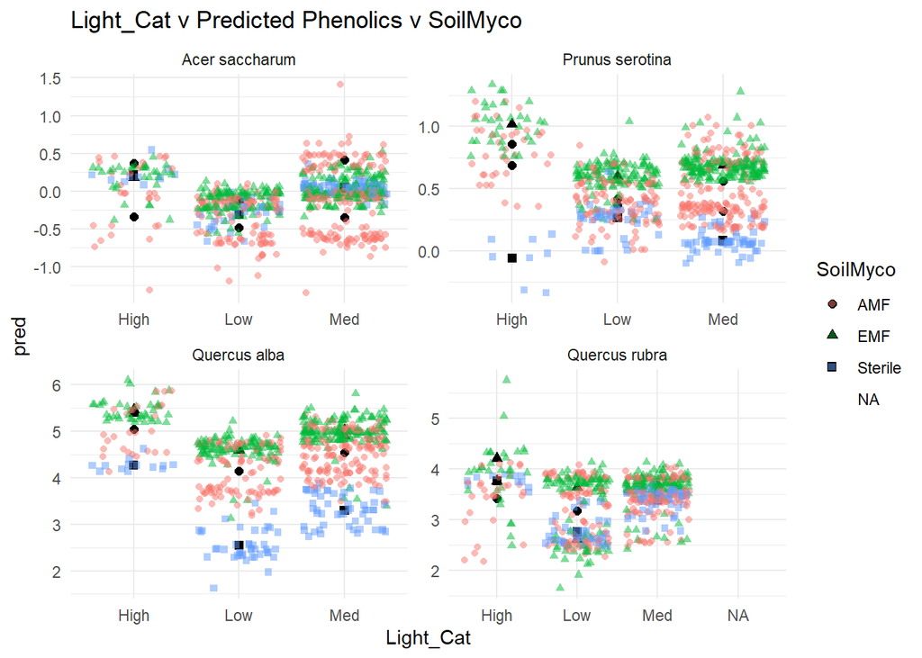

### R code

For predictive modeling of Phenolics in tree seedlings, I first created a dataframe from my clean data (tree_dat_clean) that included predictions based on my chosen model (mod1). A preview of these predictions can be seen below. While not perfect, the predictions do match up relatively well.

Through a series of dataframes and predictions, I predicted Phenolic levels for a new dataframe and plotted these predictions against the real data. For more specific information on how I did this, you can look at the r code.

In the first graph, we can see that the predicted values from the new dataframe line up fairly well with the actual data. This is especially clear in *Q. alba* where the predicted values fall pretty close to the center of the different groups. We can also see the relationships between Phenolics, Light_Cat and Conspecific quite well. *P. serotina* and *Q. alba* don’t do as well in sterile soil across all light categories, and *Q. alba* seems to do consistently best in conspecific soils.

In the second graph we see the same relationships between Phenolics and Light_Cat but we also see SoilMyco’s relationship with Phenolics. It looks like *Q. alba* has high Phenolic levels in EMF soils, slightly less in AMF soils and relatively low levels in Sterile soils. Sterile soils don’t seem to affect *Q. rubra’s* Phenolic levels very much unless it’s in a Low light category. *P. serotina* follows a similar trend to *Q. alba*, but this is confusing because *P. serotina* is categorized as an AMF in the Myco column. It would be expected that it would have higher Phenolic levels in AMF soils.

```r
df_phenolics <- tree_dat_clean %>%
  add_predictions(mod1)
df_phenolics %>% dplyr::select("Phenolics","pred")
```

```
## # A tibble: 2,782 × 2
##    Phenolics    pred
##        <dbl>   <dbl>
##  1     -0.56 -0.348
##  2      5.19  5.03
##  3      3.36  3.46
##  4     -0.71 -0.348
##  5     -0.58 -0.481
##  6      0.3   0.563
##  7      5.11  5.03
##  8      3.43  3.39
##  9      3.83  3.46
## 10     -0.05  0.0244
## # ℹ 2,772 more rows
```

```r
newdf = data.frame(Conspecific = c('Conspecific', 'Heterospecific', 'Sterilized', NA),
                   Species = c('Acer saccharum', 'Prunus serotina', 'Quercus alba', 'Quercus rubra'),
                   SoilMyco = c('AMF', 'EMF', 'Sterile', NA),
                   Light_Cat = c('Low', 'Med', 'High', NA))

pred_phenolics = predict(mod1, newdata = newdf)

hyp_preds_phenolics <- data.frame(Conspecific = newdf$Conspecific,
                         Species = newdf$Species,
                        SoilMyco = newdf$SoilMyco,
                        Light_Cat = newdf$Light_Cat,
                        pred_phenolics = pred_phenolics)

df_phenolics$PredictionType <- "Real"
hyp_preds_phenolics$PredictionType <- "Hypothetical"

fullpreds_phenolics <- full_join(df_phenolics,hyp_preds_phenolics)
```

[output not shown]

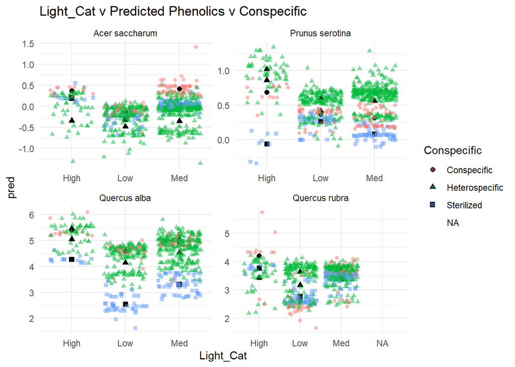

```r
ggplot(fullpreds_phenolics,aes(x=Light_Cat,y=pred, shape  = Conspecific)) +
  geom_point(size = 2) +
  geom_jitter(aes(y = Phenolics, color = Conspecific), alpha = .5) +
  theme_minimal() +
  facet_wrap(~Species, scales = 'free') +
      ggtitle('Light_Cat v Predicted Phenolics v Conspecific')
```

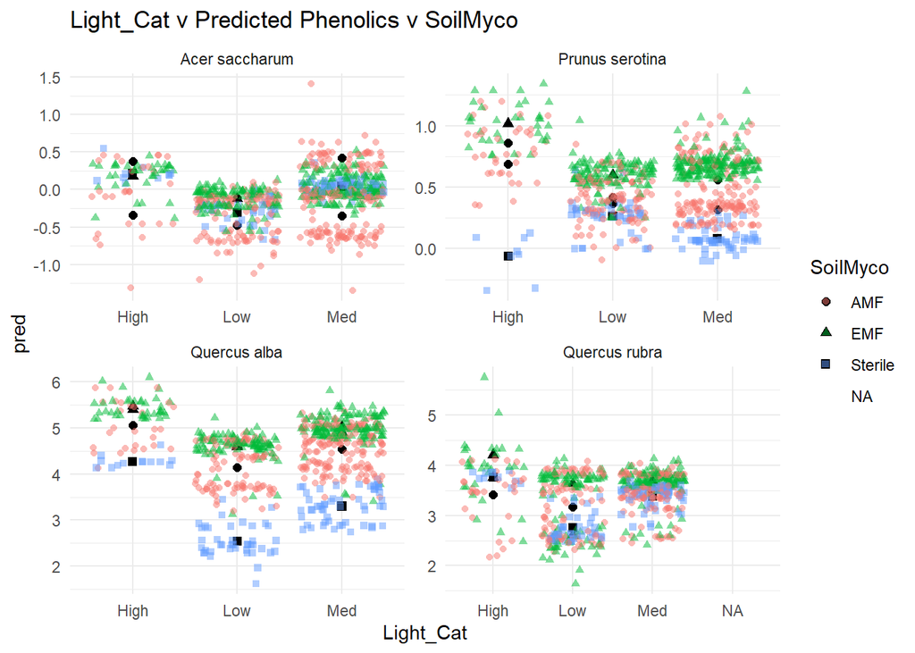

```r
ggplot(fullpreds_phenolics,aes(x=Light_Cat,y=pred, shape  = SoilMyco)) +
  geom_point(size = 2) +
  geom_jitter(aes(y = Phenolics, color = SoilMyco), alpha = .5) +
  theme_minimal() +
  facet_wrap(~Species, scales = 'free') +
      ggtitle('Light_Cat v Predicted Phenolics v SoilMyco')
```

## Lignin Modeling

### Output

The predictive modeling for Lignin used the same process as for Phenolics, but instead I used mod4. A preview of the predictions can be seen below. The predictions for Lignin also match up fairly well.

Once again the r code is available for more details on this process.

In the first graph, the predictions fit the data relatively well, but since the relationships for Lignin weren’t as clearly defined, the predictions don’t fit as well as they did for Phenolics. For *Q. alba*, there seems to be higher lignin levels in Conspecific soil when compared to Heterospecific and Sterilized soils. In *P. serotina*, seedlings in the High and Med light categories show much higher Lignin levels than seedlings in the Low light category.

In the second graph *A. saccharum* and *Q. alba* both seem to have lower Lignin levels in Sterile soils. *P. serotina* once again shows lower Lignin levels in Low light, but this graph makes it more clear that *A. saccharum* also seems to have lower Lignin levels in Low light. Since the rest of the data is rather mixed, the predictions don’t seem to track the data very well.

```
## # A tibble: 2,782 × 2
##    Lignin  pred
##     <dbl> <dbl>
##  1   13.9 13.6
##  2   20.5 20.1
##  3   24.7 25.5
##  4   14.3 13.6
##  5   10.8 11.3
##  6   10.8  9.37
##  7   18.8 20.1
##  8   25.2 24.5
##  9   26.6 25.5
## 10   13.3 13.6
## # ℹ 2,772 more rows
```

[output not shown]

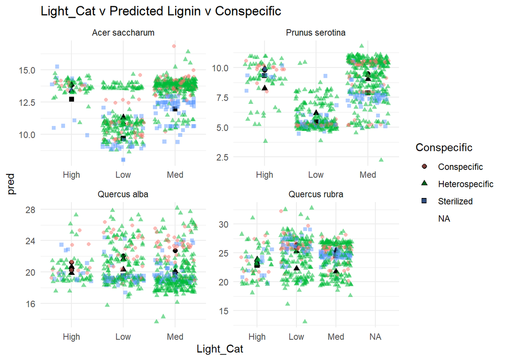

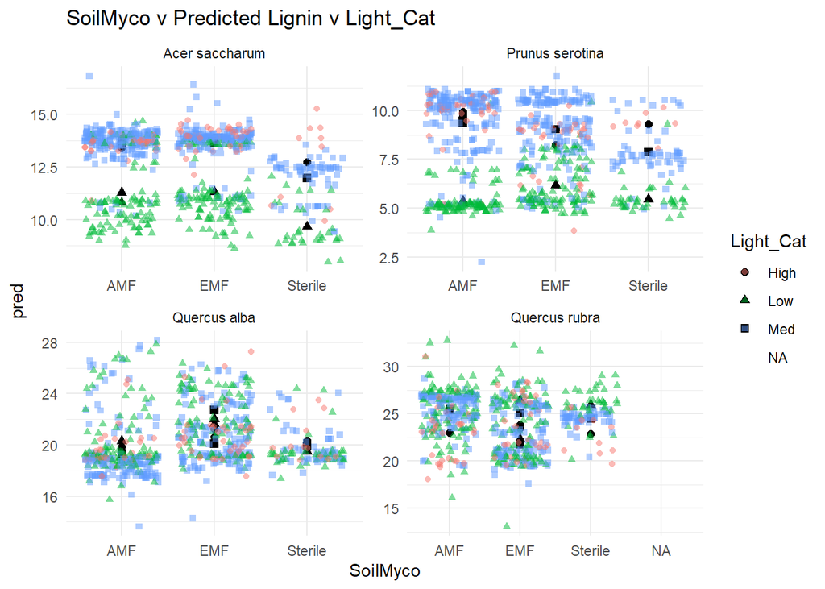

### R code

The predictive modeling for Lignin used the same process as for Phenolics, but instead I used mod4. A preview of the predictions can be seen below. The predictions for Lignin also match up fairly well.

Once again the r code is available for more details on this process.

In the first graph, the predictions fit the data relatively well, but since the relationships for Lignin weren’t as clearly defined, the predictions don’t fit as well as they did for Phenolics. For *Q. alba*, there seems to be higher lignin levels in Conspecific soil when compared to Heterospecific and Sterilized soils. In *P. serotina*, seedlings in the High and Med light categories show much higher Lignin levels than seedlings in the Low light category.

In the second graph *A. saccharum* and *Q. alba* both seem to have lower Lignin levels in Sterile soils. *P. serotina* once again shows lower Lignin levels in Low light, but this graph makes it more clear that *A. saccharum* also seems to have lower Lignin levels in Low light. Since the rest of the data is rather mixed, the predictions don’t seem to track the data very well.

```r
df_lignin <- tree_dat_clean %>%
  add_predictions(mod4)
df_lignin %>% dplyr::select("Lignin","pred")
```

```
## # A tibble: 2,782 × 2
##    Lignin  pred
##     <dbl> <dbl>
##  1   13.9 13.6
##  2   20.5 20.1
##  3   24.7 25.5
##  4   14.3 13.6
##  5   10.8 11.3
##  6   10.8  9.37
##  7   18.8 20.1
##  8   25.2 24.5
##  9   26.6 25.5
## 10   13.3 13.6
## # ℹ 2,772 more rows
```

```r
pred_lignin = predict(mod4, newdata = newdf)

hyp_preds_lignin <- data.frame(Conspecific = newdf$Conspecific,
                                  Species = newdf$Species,
                                  SoilMyco = newdf$SoilMyco,
                                  Light_Cat = newdf$Light_Cat,
                                  pred_lignin = pred_lignin)

df_lignin$PredictionType <- "Real"
hyp_preds_lignin$PredictionType <- "Hypothetical"

fullpreds_lignin <- full_join(df_lignin,hyp_preds_lignin)
```

[output not shown]

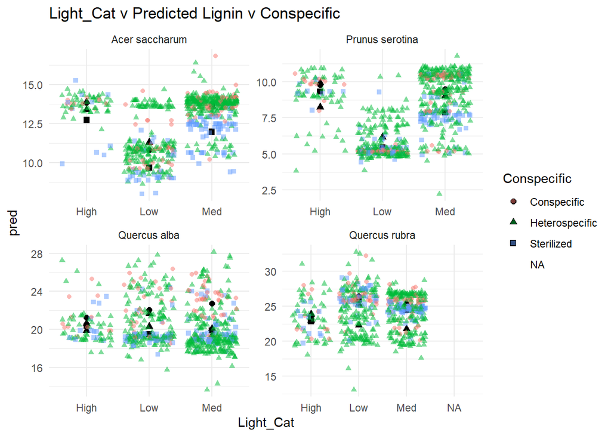

```r
ggplot(fullpreds_lignin,aes(x=Light_Cat,y=pred, shape  = Conspecific)) +
  geom_point(size = 2) +
  geom_jitter(aes(y = Lignin, color = Conspecific), alpha = .5) +
  theme_minimal() +
  facet_wrap(~Species, scales = 'free') +
        ggtitle('Light_Cat v Predicted Lignin v Conspecific')
```

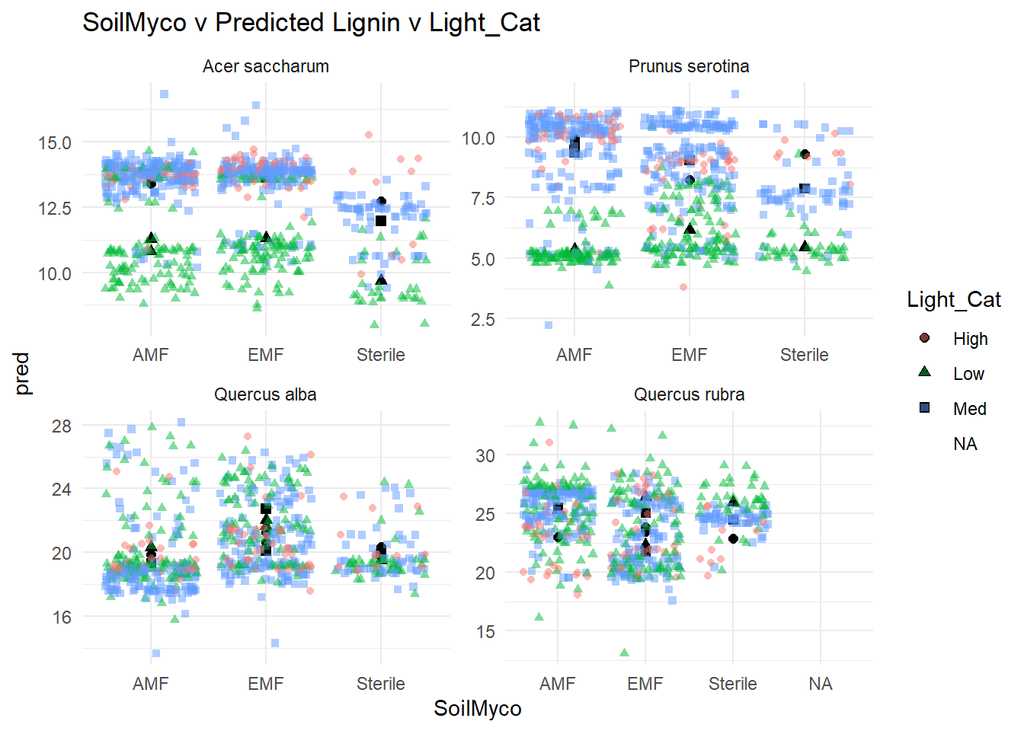

```r
ggplot(fullpreds_lignin,aes(x=SoilMyco,y=pred, shape  = Light_Cat)) +
  geom_point(size = 2) +
  geom_jitter(aes(y = Lignin, color = Light_Cat), alpha = .5) +
  theme_minimal() +
  facet_wrap(~Species, scales = 'free') +
        ggtitle('SoilMyco v Predicted Lignin v Light_Cat')
```

## NSC modeling

### Output

The predictive modeling for NSC used the same process as for Phenolics and Lignin, but instead I used mod7. A preview of the predictions can be seen below. The predictions for NSC also match up quite well with the real values.

Once again the r code is available for more details on this process.

In the first graph much of the data is intermixed and the predictions are rather clumped together. For *P. serontina*, the predicted values for NSC are higher in High and Med light levels which tracks very well with the actual data.

```
## # A tibble: 2,782 × 2
##      NSC  pred
##    <dbl> <dbl>
##  1  12.2  12.1
##  2  19.3  20.1
##  3  15.0  14.7
##  4  12.4  12.1
##  5  11.2  10.9
##  6  13.8  12.4
##  7  22.5  20.1
##  8  14.8  14.8
##  9  14.6  14.7
## 10  12.2  12.2
## # ℹ 2,772 more rows
```

[output not shown]

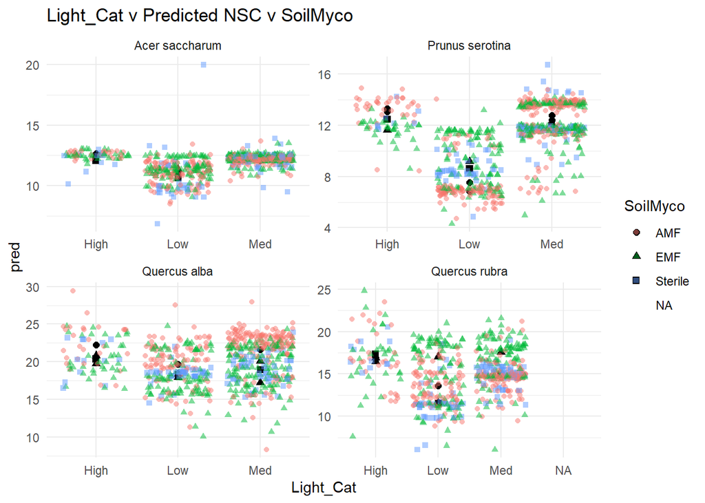

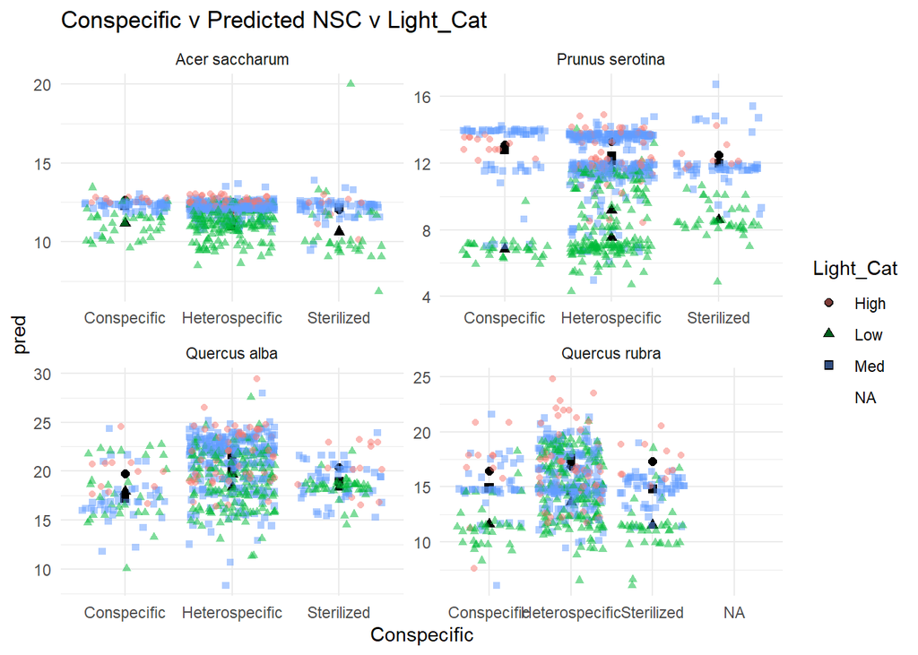

### R code

The predictive modeling for NSC used the same process as for Phenolics and Lignin, but instead I used mod7. A preview of the predictions can be seen below. The predictions for NSC also match up quite well with the real values.

Once again the r code is available for more details on this process.

In the first graph much of the data is intermixed and the predictions are rather clumped together. For *P. serontina*, the predicted values for NSC are higher in High and Med light levels which tracks very well with the actual data.

```r
df_NSC <- tree_dat_clean %>%
  add_predictions(mod7)
df_NSC %>% dplyr::select("NSC","pred")
```

```
## # A tibble: 2,782 × 2
##      NSC  pred
##    <dbl> <dbl>
##  1  12.2  12.1
##  2  19.3  20.1
##  3  15.0  14.7
##  4  12.4  12.1
##  5  11.2  10.9
##  6  13.8  12.4
##  7  22.5  20.1
##  8  14.8  14.8
##  9  14.6  14.7
## 10  12.2  12.2
## # ℹ 2,772 more rows
```

```r
pred_NSC = predict(mod7, newdata = newdf)

hyp_preds_NSC <- data.frame(Conspecific = newdf$Conspecific,
                                  Species = newdf$Species,
                                  SoilMyco = newdf$SoilMyco,
                                  Light_Cat = newdf$Light_Cat,
                                  pred_NSC = pred_NSC)

df_NSC$PredictionType <- "Real"
hyp_preds_NSC$PredictionType <- "Hypothetical"

fullpreds_NSC <- full_join(df_NSC,hyp_preds_NSC)
```

[output not shown]

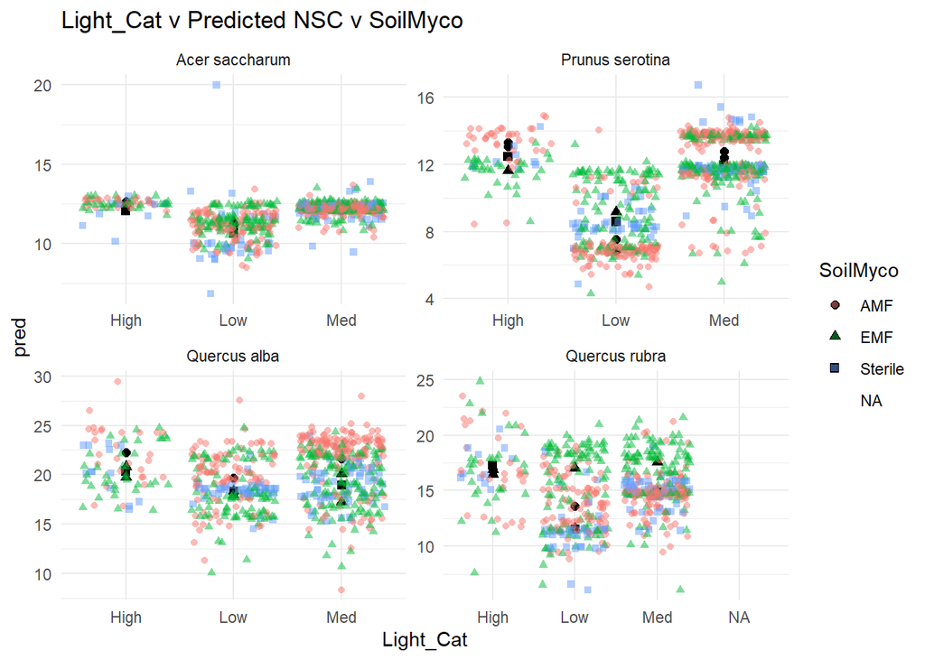

```r
ggplot(fullpreds_NSC,aes(x=Light_Cat,y=pred, shape  = SoilMyco)) +
  geom_point(size = 2) +
  geom_jitter(aes(y = NSC, color = SoilMyco), alpha = .5) +
  theme_minimal() +
  facet_wrap(~Species, scales = 'free') +
        ggtitle('Light_Cat v Predicted NSC v SoilMyco')
```

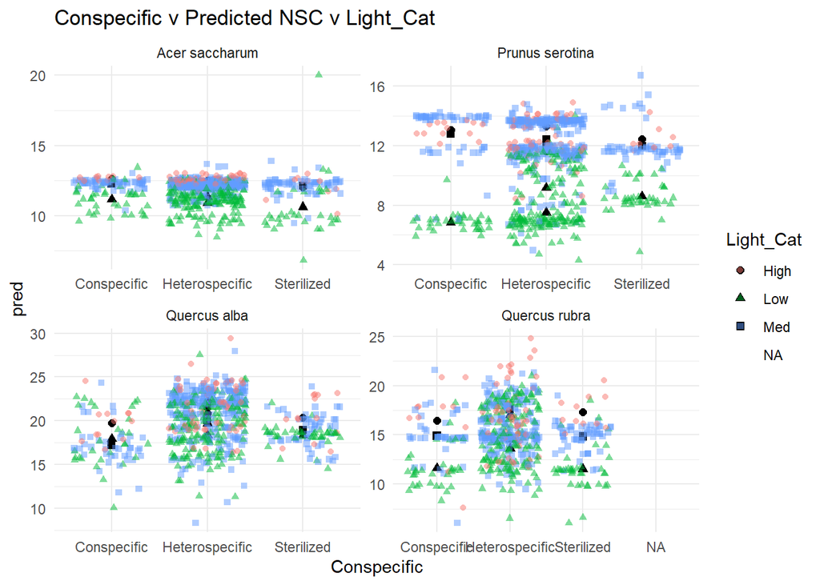

```r
ggplot(fullpreds_NSC,aes(x=Conspecific,y=pred, shape  = Light_Cat)) +
  geom_point(size = 2) +
  geom_jitter(aes(y = NSC, color = Light_Cat), alpha = .5) +
  theme_minimal() +
  facet_wrap(~Species, scales = 'free') +
          ggtitle('Conspecific v Predicted NSC v Light_Cat')
```

# Shiny App

https://t6syzy-jessica-richards.shinyapps.io/shiny_app_stuff/

# Conclusions

Based on the plots and models, the largest factors in determining Phenolics, Lignin, and NSC were Species and Light_Cat. High and Med light categories are associated with higher levels of Phenolics in *A. saccharum*, *P. serotina*, and *Q. alba*. High and Med light categories were also associated with higher levels of Lignin and NSC in *P. serotina*.

Other less influential factors were Conspecific, SoilMyco, and AMF. *P. serotina* showed a positive relationship between Phenolic levels and AMF levels. *P. serotina* and *Q. alba* had lower phenolic levels in sterilized soils, they may have also showed lower Lignin and NSC levels in sterilized soils but the relationship was less clear. *Q. alba* also higher Phenolic levels in conspecific soils and soils with EMF. Interestingly, *P. serontina* had higher Phenolic levels in heterospecific soils and soils with EMF even though the Myco of *P. serontina* is AMF.